# Moderate Food Poverty: A Global Challenge

### Tracking Moderate Poverty Dynamics Across Continents

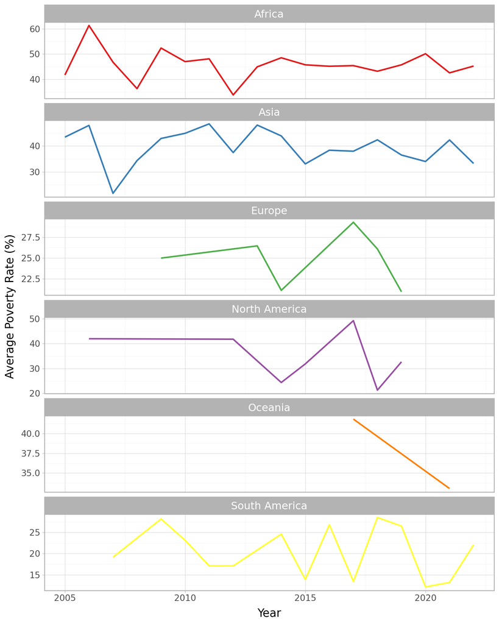

```python
## Plotting facets for line chart
(
    ggplot(timeseries, aes(x='year', y='obs_value', color='continent')) +
    geom_line(size=1) +
    facet_wrap("continent", ncol=1, scales='free_y') +
    scale_color_brewer(type='qual', palette='Set1') +
    labs(
        x='Year',
        y='Average Poverty Rate (%)'
    ) +
    theme_light() +
    theme(
        figure_size=(8, 10),
        plot_title=element_text(size=16),
        axis_title=element_text(size=13),
        axis_text=element_text(size=10),
        strip_text=element_text(size=12),
        legend_position='none'
    )
)
```

## Conclusion

Food poverty remains a persistent barrier to healthy childhood development around the world. The early years of a child’s life are critical for building a strong foundation in health, learning and well-being. When children lack access to basic nutrition, the consequences ripple through their future. Addressing food poverty is not just about feeding children today, but about securing their tomorrow.Despite the challenges, the smiles of children remind us of what is possible when support reaches those who need it most. Investing in the earliest years of life is one of the most effective ways to combat food poverty. Countries that prioritize early childhood care and nutrition show not only improved health outcomes but also higher life expectancy. Every child fed, every child supported, is a step closer to a more just and thriving world.